# Sosiaalisen median aktiivikäyttö ja syntyvyys

Antti J. Tanskanen, Elinkeinoelämän keskusliitto EK

1.3.2023

## Johdanto

Syntyneiden lasten määrä on Suomessa laskenut 61 000 lapsesta vuonna 2010 noin 50 300:ään vuonna 2017. Alkuvuoden 2018 luvuilla laskemalla vaikuttaa siltä että tämän vuoden syntyneden määrä jää ehkä 48 000:een ja hedelmällisyysluku 1,43:een alle vuoden 1973 pohjien. Laskeva trendi on jatkunut koko aikavälin 2010-2018, joten satunnaisvaihtelusta tuskin on kysymys. Osan syntyneiden lukumäärän laskusta selittää synnytysikäisten naisten lukumäärän pieneneminen, mutta ei läheskään kaikkea. Muiksi selityksiksi on tarjottu mm. työttömyyttä (Hiilamo, 2017) ja miesten heikkoa työsuhteeseen kiinnittymistä (Miettinen ja Jalovaara, 2015). Muissa maissa syntyvyyden laskun on arvioitu aiheutuvan mm. lapsikuolleisuuden vähenemisestä (Becker ja Barro, 1988), kaupungistumisesta (Martine et al., 2013) ja vanhuuseläkkeiden korkeammasta korvausasteesta (Boldrin et al., 2015). Sen lisäksi että työttömyys alentaisi syntyvyyttä, taloudellisten kriisien on myös havaittu lisänneen syntyvyyttä (Kohler ja Kohler, 2002).

Syntyneiden määrällä on viiveellä vaikutusta työikäisen väestön määrään, ja sitä kautta syntyvyyden laskulla on vaikutuksia mm. sosiaaliturvan rahoituksen kestävyyteen. Eläketurvakeskuksen laskelmien mukaan syntyvyyden lasku aiheuttaa työeläkemaksussa pitkällä aikavälillä useiden prosenttiyksiköiden nousupaineen (Tikanmäki, 2017). Myös Väestöntutkimuslaitos on analysoinut syitä syntyvyyden laskulle, mutta selkeätä syytä ei ole löytynyt (Rotkirch et al, 2017)

Tässä tutkimuksessa jatketaan aiemman harjoituksen mallilla ja kokeillaan miten hyvin ennuste toimii. Tämän lisäksi tutkimuksessa pyritään tarkastelemaan, onko sosiaalisen median aktiivikäytön lisääntymisellä kytkentää syntyvyyden laskuun.

## Aineisto

Työllisyyttä (Tilastokeskus) kuvataan 10-vuotisikäluokittaisilla työllisyysasteilla sukupuolittain, 10-vuotisikäluokkakohtaisista työttömyysasteista sukupuolittain (suhteutettu ikäluokan kokoon, ), ja työsuhteiden tyyppitiedoilla (jatkuva/määräaikainen; kokoaikainen/osa-aikainen) vuosilta 1997-2017. Kaupungistumista kuvaa sisemmässä kaupungissa, ulommassa kaupungissa ja kehyskaupungissa asuvien osuudet väestöstä (Tilastokeskus)

Verrattuna aiempiin harjoitelmiin, mukaan on otettu myös sosiaalisen median aktiivikäyttäjien osuus Tilastokeskuksen Viestintä- ja tietotekniikan käyttö-tutkimuksesta (“Seuraa jotain yhteisöpalvelua yleensä jatkuvasti kirjautuneena tai useasti päivässä”).

Aineiston perusteella ei voi tehdä kausaalisia päätelmiä, ainostaan assosiatiivisuutta koskevia. Tämä tietenkin rajoittaa tulkintamahdollisuuksia.

Tarkoituksena on avoimen, toistettavan tutkimuksen hengessä näyttää täsmällisesti mitä on tehty. Tästä syystä alkuperäinen aineisto (myös tämä työkirja koodeineen, Rmd-muotoisena; data Rdata-muodossa) on kokonaisuudessaan saatavissa osoitteesta https://github.com/ajtanskanen/Syntyvyyden-tekij-t

```
## # A tibble: 32 × 68
##    vuosi hedelmallisyysluku tfr_lin pienituloisuus_miehet_18_29
##    <dbl>              <dbl>   <dbl>                       <dbl>
##  1  1990               1.79    1.79                         7.9
##  2  1991               1.8     1.8                         10.9
##  3  1992               1.85    1.85                        13.5
##  4  1993               1.81    1.81                        12.7
##  5  1994               1.85    1.85                        14.2
##  6  1995               1.81    1.81                        15.9
##  7  1996               1.76    1.76                        19.3
##  8  1997               1.75    1.75                        18.2
##  9  1998               1.71    1.71                        17.9
## 10  1999               1.73    1.73                        18.2
## # ℹ 22 more rows
## # ℹ 64 more variables: pienituloisuus_naiset_18_29 <dbl>,
## #   lapsikuolleisuus <dbl>, synnyttajien_keskiika <dbl>, sisempikaupunki <dbl>,
## #   ulompikaupunki <dbl>, kehyskaupunki <dbl>, maaseudulla <dbl>,
## #   avioituvuus_naiset_30_34 <dbl>, avioituvuus_naiset_25_29 <dbl>,
## #   eronneisuus_25_29 <dbl>, eronneisuus_30_34 <dbl>,
## #   kolmasaste_miehet_25_29 <dbl>, miehet_perusaste_25_29 <dbl>, …
```

| vuosi | hedelmallisyysluku | tfr_lin | pienituloisuus_miehet_18_29 | pienituloisuus_naiset_18_29 | lapsikuolleisuus | synnyttajien_keskiika | sisempikaupunki | ulompikaupunki | kehyskaupunki | maaseudulla | avioituvuus_naiset_30_34 | avioituvuus_naiset_25_29 | eronneisuus_25_29 | eronneisuus_30_34 | kolmasaste_miehet_25_29 | miehet_perusaste_25_29 | naiset_perusaste_25_29 | kolmasaste_naiset_25_29 | alypuhelin | some_25_34 | some_35_44 | työttömyys_miehet_25_34 | työttömyys_naiset_25_34 | työllisyysaste_miehet_25_34 | työllisyysaste_naiset_25_34 | työttömyys_miehet_35_44 | työttömyys_naiset_35_44 | työllisyysaste_miehet_35_44 | työllisyysaste_naiset_35_44 | … |
| --- | --- | --- | --- | --- | --- | --- | --- | --- | --- | --- | --- | --- | --- | --- | --- | --- | --- | --- | --- | --- | --- | --- | --- | --- | --- | --- | --- | --- | --- | --- |
| 1990 | 1.79 | 1.79 | 7.9 | 11.4 | 0.005656 | 29.16007 | 29.07553 | 23.47094 | 9.400502 | 36.74539 | 51.4 | 87.5 | 24.5 | 20.9 | 22.20520 | 20.39246 | 14.71725 | 32.80953 | 0.0 | 0.000000 | 0.000000 | 2.7 | 2.1 | 90.7 | 80.6 | 2.7 | 1.5 | 92.1 | 88.3 | … |
| 1991 | 1.80 | 1.80 | 10.9 | 13.2 | 0.005804 | 29.17025 | 28.98024 | 23.76895 | 9.459372 | 36.58865 | 50.5 | 86.0 | 24.5 | 21.5 | 22.45398 | 20.71139 | 14.82640 | 33.94811 | 0.0 | 0.000000 | 0.000000 | 5.9 | 2.8 | 86.9 | 78.3 | 4.5 | 2.4 | 89.9 | 86.5 | … |
| 1992 | 1.85 | 1.85 | 13.5 | 13.9 | 0.005168 | 29.27384 | 28.86376 | 24.03029 | 9.515346 | 36.40213 | 49.5 | 81.1 | 25.3 | 21.8 | 22.90123 | 20.99995 | 14.83536 | 35.35189 | 0.0 | 0.000000 | 0.000000 | 12.6 | 7.7 | 78.8 | 72.5 | 10.6 | 6.0 | 83.6 | 81.4 | … |
| 1993 | 1.81 | 1.81 | 12.7 | 13.8 | 0.004299 | 29.36066 | 28.91661 | 24.22639 | 9.541993 | 36.18564 | 53.6 | 84.8 | 23.8 | 21.6 | 23.51026 | 21.11124 | 15.00487 | 36.81922 | 0.0 | 0.000000 | 0.000000 | 18.5 | 14.0 | 72.5 | 66.5 | 15.3 | 10.2 | 78.6 | 77.8 | … |
| 1994 | 1.85 | 1.85 | 14.2 | 16.6 | 0.004729 | 29.50438 | 29.13594 | 24.35195 | 9.520954 | 35.86900 | 54.2 | 84.1 | 24.9 | 23.4 | 24.20501 | 21.07767 | 15.20491 | 38.05622 | 0.0 | 0.000000 | 0.000000 | 20.8 | 16.5 | 70.8 | 64.0 | 16.6 | 12.7 | 77.0 | 76.3 | … |
| 1995 | 1.81 | 1.81 | 15.9 | 17.1 | 0.003858 | 29.68761 | 29.44644 | 24.41879 | 9.517619 | 35.48700 | 52.6 | 78.5 | 27.1 | 24.7 | 24.96074 | 21.02787 | 15.22944 | 39.31916 | 0.0 | 0.000000 | 0.000000 | 16.1 | 16.9 | 74.9 | 62.7 | 13.4 | 12.6 | 80.1 | 77.1 | … |
| 1996 | 1.76 | 1.76 | 19.3 | 20.3 | 0.003896 | 29.75513 | 29.69213 | 24.46521 | 9.524036 | 35.11732 | 55.4 | 78.5 | 27.7 | 23.5 | 25.61609 | 20.96593 | 15.16406 | 40.38486 | 0.0 | 0.000000 | 0.000000 | 15.1 | 16.4 | 75.6 | 63.5 | 12.4 | 11.1 | 80.4 | 78.4 | … |
| 1997 | 1.75 | 1.75 | 18.2 | 21.5 | 0.003859 | 29.85207 | 29.93875 | 24.52692 | 9.559717 | 34.74476 | 51.1 | 75.5 | 28.0 | 24.6 | 26.21721 | 20.83784 | 15.13552 | 41.65961 | 0.0 | 0.000000 | 0.000000 | 13.2 | 15.5 | 77.3 | 64.1 | 10.8 | 11.0 | 81.3 | 76.9 | … |
| 1998 | 1.71 | 1.71 | 17.9 | 22.4 | 0.004106 | 29.93836 | 30.16273 | 24.59814 | 9.606589 | 34.36780 | 52.7 | 74.8 | 27.0 | 26.1 | 26.66281 | 20.58038 | 14.71967 | 42.82898 | 0.0 | 0.000000 | 0.000000 | 11.6 | 13.0 | 78.6 | 66.6 | 10.2 | 8.6 | 83.0 | 79.1 | … |
| 1999 | 1.73 | 1.73 | 18.2 | 23.1 | 0.003643 | 29.94829 | 30.31594 | 24.74187 | 9.700420 | 34.18984 | 53.0 | 74.4 | 29.6 | 27.6 | 26.94710 | 19.89138 | 13.92199 | 43.48910 | 0.0 | 0.000000 | 0.000000 | 10.6 | 11.9 | 80.5 | 68.3 | 8.0 | 8.7 | 85.6 | 80.4 | … |
| 2000 | 1.73 | 1.73 | 16.7 | 21.7 | 0.003703 | 29.93065 | 30.46935 | 24.85905 | 9.785056 | 33.82567 | 59.1 | 76.9 | 29.3 | 26.3 | 26.62361 | 18.79471 | 13.07177 | 43.65627 | 0.0 | 0.100625 | 0.056875 | 9.8 | 12.1 | 82.3 | 68.6 | 7.7 | 9.8 | 84.9 | 79.3 | … |
| 2001 | 1.73 | 1.73 | 19.2 | 21.8 | 0.003222 | 29.93799 | 30.63816 | 25.00088 | 9.862325 | 33.45721 | 55.2 | 72.7 | 28.5 | 26.8 | 26.29434 | 17.89423 | 12.26555 | 43.67506 | 0.0 | 0.201250 | 0.113750 | 7.9 | 11.6 | 83.6 | 68.3 | 6.8 | 8.4 | 86.6 | 80.3 | … |
| 2002 | 1.72 | 1.72 | 21.0 | 22.4 | 0.003055 | 29.94876 | 30.68754 | 25.14669 | 9.953700 | 33.17434 | 59.7 | 79.4 | 27.9 | 27.2 | 26.25954 | 17.00937 | 11.46027 | 43.79083 | 0.0 | 0.402500 | 0.227500 | 8.8 | 9.6 | 82.6 | 72.8 | 7.1 | 6.8 | 85.5 | 82.2 | … |
| 2003 | 1.76 | 1.76 | 21.1 | 23.2 | 0.003122 | 29.99949 | 30.71711 | 25.27496 | 10.033216 | 32.92671 | 59.8 | 75.6 | 27.2 | 25.9 | 26.13405 | 16.52893 | 11.06241 | 43.56587 | 0.0 | 0.805000 | 0.455000 | 8.0 | 9.5 | 83.2 | 72.2 | 7.6 | 6.5 | 84.1 | 82.3 | … |
| 2004 | 1.80 | 1.80 | 20.9 | 24.8 | 0.003345 | 29.99861 | 30.68952 | 25.41501 | 10.148472 | 32.74767 | 69.1 | 81.1 | 27.8 | 25.2 | 25.54432 | 16.66686 | 10.78615 | 42.97749 | 0.0 | 1.610000 | 0.910000 | 9.3 | 9.1 | 82.7 | 70.0 | 7.2 | 7.8 | 85.6 | 79.2 | … |
| 2005 | 1.80 | 1.80 | 21.5 | 24.8 | 0.003029 | 29.98396 | 30.68325 | 25.53853 | 10.259743 | 32.52438 | 71.8 | 80.5 | 28.5 | 25.3 | 24.71607 | 17.44605 | 11.05609 | 41.88766 | 0.6 | 3.220000 | 1.820000 | 8.4 | 8.8 | 82.1 | 72.9 | 7.3 | 7.1 | 85.7 | 80.4 | … |
| 2006 | 1.84 | 1.84 | 20.7 | 23.2 | 0.002864 | 30.01663 | 30.68084 | 25.68068 | 10.369200 | 32.25263 | 69.1 | 77.0 | 28.3 | 24.3 | 24.04813 | 17.97995 | 11.17615 | 41.03960 | 1.6 | 5.060000 | 2.860000 | 7.2 | 8.2 | 83.3 | 73.3 | 5.3 | 6.7 | 87.1 | 81.2 | … |
| 2007 | 1.83 | 1.83 | 22.4 | 22.5 | 0.002735 | 30.03735 | 30.68097 | 25.82609 | 10.468855 | 31.99119 | 73.3 | 78.8 | 27.9 | 25.6 | 23.16005 | 18.81623 | 11.66691 | 40.02624 | 3.6 | 8.280000 | 4.680000 | 6.5 | 7.4 | 83.4 | 73.9 | 4.6 | 6.3 | 87.9 | 81.7 | … |
| 2008 | 1.85 | 1.85 | 22.9 | 23.7 | 0.002633 | 30.08387 | 30.80139 | 25.92121 | 10.552420 | 31.67928 | 75.1 | 80.5 | 29.3 | 26.2 | 23.49941 | 19.64056 | 12.02829 | 41.20856 | 6.6 | 11.500000 | 6.500000 | 5.5 | 6.2 | 86.3 | 73.9 | 4.2 | 5.8 | 88.8 | 83.1 | … |
| 2009 | 1.86 | 1.86 | 23.6 | 25.7 | 0.002722 | 30.07964 | 30.91861 | 25.98049 | 10.620027 | 31.41084 | 72.7 | 76.5 | 30.4 | 26.2 | 23.09035 | 19.79246 | 12.43646 | 40.38255 | 11.6 | 17.480000 | 9.880000 | 8.1 | 8.1 | 82.6 | 72.7 | 5.1 | 5.7 | 88.9 | 82.4 | … |
| 2010 | 1.87 | 1.87 | 24.5 | 25.1 | 0.002286 | 30.14016 | 31.01223 | 26.07021 | 10.670150 | 31.14255 | 73.6 | 75.9 | 30.7 | 26.8 | 23.57718 | 19.76929 | 12.64248 | 40.41627 | 18.6 | 21.160000 | 11.960000 | 9.4 | 8.5 | 81.1 | 71.1 | 7.1 | 5.7 | 86.1 | 82.5 | … |
| 2011 | 1.83 | 1.83 | 23.7 | 24.4 | 0.002341 | 30.25649 | 31.15617 | 26.14298 | 10.723169 | 30.84460 | 70.2 | 68.9 | 29.8 | 24.9 | 23.44754 | 19.77233 | 13.00261 | 40.28839 | 28.6 | 23.000000 | 13.000000 | 8.2 | 7.4 | 82.8 | 69.8 | 7.5 | 5.9 | 86.2 | 81.3 | … |
| 2012 | 1.80 | 1.80 | 24.2 | 22.9 | 0.002352 | 30.33253 | 31.34657 | 26.20222 | 10.796668 | 30.52489 | 66.4 | 69.6 | 29.5 | 25.4 | 23.62948 | 19.64206 | 13.29809 | 40.27121 | 38.6 | 21.000000 | 13.000000 | 7.9 | 7.5 | 81.6 | 70.6 | 5.9 | 4.9 | 86.5 | 82.5 | … |
| 2013 | 1.75 | 1.75 | 28.0 | 25.8 | 0.001726 | 30.43563 | 31.56901 | 26.24456 | 10.831568 | 30.19933 | 59.8 | 59.7 | 31.7 | 26.7 | 24.18749 | 19.07700 | 13.30760 | 40.54371 | 51.5 | 26.000000 | 18.000000 | 7.7 | 7.9 | 81.3 | 68.7 | 5.9 | 6.7 | 86.7 | 79.9 | … |
| 2014 | 1.71 | 1.71 | 30.6 | 27.5 | 0.002137 | 30.47105 | 31.82057 | 26.24797 | 10.884208 | 29.87697 | 57.6 | 56.7 | 33.4 | 28.2 | 24.39030 | 18.70532 | 13.60838 | 40.07974 | 61.5 | 33.000000 | 19.000000 | 9.6 | 7.8 | 78.8 | 69.7 | 6.4 | 6.3 | 85.2 | 79.5 | … |
| 2015 | 1.65 | 1.65 | 29.7 | 28.1 | 0.001718 | 30.59956 | 32.05831 | 26.30111 | 10.936146 | 29.50893 | 56.0 | 54.7 | 32.2 | 28.2 | 24.36150 | 18.81550 | 14.03869 | 39.29264 | 68.4 | 44.000000 | 27.000000 | 10.4 | 10.5 | 78.7 | 67.6 | 7.6 | 6.3 | 84.1 | 79.4 | … |
| 2016 | 1.57 | 1.57 | 26.2 | 27.1 | 0.001831 | 30.79952 | 32.24616 | 26.36616 | 10.977674 | 29.12863 | 53.8 | 52.6 | 31.2 | 27.5 | 24.52337 | 18.75504 | 14.06125 | 38.84403 | 74.9 | 55.000000 | 41.000000 | 9.6 | 9.7 | 79.3 | 67.6 | 6.6 | 7.5 | 85.5 | 79.1 | … |
| 2017 | 1.49 | 1.49 | 26.3 | 27.7 | 0.001955 | 30.90000 | 32.52178 | 26.39140 | 11.042493 | 28.75278 | 51.1 | 48.7 | 31.1 | 27.3 | 24.59459 | 18.22492 | 13.75754 | 38.85254 | 79.1 | 57.000000 | 41.000000 | 9.7 | 7.5 | 78.1 | 70.1 | 7.5 | 6.2 | 84.5 | 79.4 | … |
| 2018 | 1.41 | 1.41 | 28.5 | 30.3 | 0.002028 | 31.00000 | 32.79740 | 26.41663 | 11.107312 | 28.37693 | 46.6 | 45.3 | 28.0 | 27.9 | 25.62926 | 16.64358 | 12.07871 | 39.81549 | 80.0 | 53.000000 | 47.000000 | 9.2 | 9.7 | 80.2 | 69.2 | 5.5 | 5.9 | 86.3 | 81.3 | … |
| 2019 | 1.35 | 1.33 | 27.8 | 31.6 | 0.002050 | 31.20000 | 33.07302 | 26.44187 | 11.172132 | 28.00107 | 42.9 | 39.3 | 29.4 | 28.1 | 26.03882 | 16.47696 | 12.00570 | 40.01437 | 83.0 | 74.000000 | 45.202500 | 7.1 | 7.3 | 81.5 | 71.3 | 5.0 | 4.8 | 87.6 | 82.0 | … |
| 2020 | 1.37 | 1.25 | 25.1 | 28.7 | 0.001859 | 31.30000 | 33.34864 | 26.46711 | 11.236951 | 27.62522 | 42.5 | 36.3 | 29.8 | 28.9 | 26.83435 | 16.41897 | 12.01528 | 40.60123 | 87.0 | 85.000000 | 47.010600 | 7.3 | 7.1 | 81.1 | 73.0 | 4.2 | 3.8 | 87.9 | 82.1 | … |
| 2021 | 1.46 | 1.17 | 28.1 | 31.9 | 0.001828 | 31.60000 | 33.62426 | 26.49235 | 11.301770 | 27.24937 | 40.7 | 35.0 | 29.1 | 25.3 | 27.28595 | 16.66435 | 12.19444 | 41.21560 | 88.0 | 81.000000 | 73.000000 | 8.7 | 7.8 | 78.7 | 75.7 | 6.3 | 5.4 | 87.2 | 85.8 | … |

# Hedelmällisyysluvun muutoksia selittävä malli

Synnytysikäisten naisten lukumäärää pystytään lyhyellä aikavälillä ennustamaan melko hyvin, eikä siihen vaikuta juurikaan muut tekijät, kuten vaikkapa työllisyys tai taloudellinen tilanne. Jos jokin vaikuttaa syntyvyyteen, vaikutuksen pitäisi näkyä hedelmällisyysluvussa.

Yritetään sitten selittää hedelmällisyysluvun muutoksia käyttäen faktoreina kokoelmaa erilaisia tekijöitä ikäluokka- ja sukupuolikohtaisia avioituvuuksia ja pienituloisuusosuusasteita (60% mediaanitulosta); synnyttäjien keski-ikää, alle 1-vuotiaiden kuolleisuutta, sekä sisäkaupungissa, ulkokaupungissa ja kehyskaupungissa asuvien osuutta väestöstä. Lisäksi mukana on 25-34- ja 35-44 -vuotiaiden somen aktiivikäyttäjien osuus väestöstä.

```
##                               P(B != 0 | Y) model 1 model 2 model 3
## Intercept                             1.000   1.000   1.000   1.000
## lapsikuolleisuus                      0.150   0.000   0.000   0.000
## avioituvuus_naiset_25_29_lag1         0.198   0.000   0.000   0.000
## avioituvuus_naiset_30_34_lag1         0.974   1.000   1.000   1.000
## some_35_44_lag1                       0.511   1.000   0.000   0.000
## maaseudulla                           0.866   1.000   1.000   1.000
## some_25_44_diff_lag1                  0.769   1.000   1.000   0.000
## dummy2021                             0.361   0.000   0.000   1.000
## BF                                       NA   1.000   0.543   0.442
## PostProbs                                NA   0.214   0.184   0.121
## R2                                       NA   0.961   0.950   0.950
## dim                                      NA   5.000   4.000   4.000
## logmarg                                  NA  36.232  35.621  35.416
```

Regressiokertoimet todennäköisimmässä mallissa ovat

```
##
##  Marginal Posterior Summaries of Coefficients:
##
##  Using  HPM
##
##  Based on the top  1 models
##                                post mean  post SD    post p(B != 0)
## Intercept                       1.720000   0.005592   1.000000
## lapsikuolleisuus                0.000000   0.000000   0.149609
## avioituvuus_naiset_25_29_lag1   0.000000   0.000000   0.198047
## avioituvuus_naiset_30_34_lag1   0.009891   0.001091   0.973828
## some_35_44_lag1                -0.003314   0.001249   0.511328
## maaseudulla                     0.036635   0.006853   0.866016
## some_25_44_diff_lag1            0.005472   0.001272   0.769141
## dummy2021                       0.000000   0.000000   0.360938
```

Aggregaattikertoimet kaikissa mallissa todennäköisyyksillä painotettuna ovat

```
##
##  Marginal Posterior Summaries of Coefficients:
##
##  Using  BMA
##
##  Based on the top  59 models
##                                post mean   post SD     post p(B != 0)
## Intercept                       1.7200000   0.0060810   1.0000000
## lapsikuolleisuus               -1.1448653  13.3452359   0.1496094
## avioituvuus_naiset_25_29_lag1   0.0008057   0.0032848   0.1980469
## avioituvuus_naiset_30_34_lag1   0.0100843   0.0030498   0.9738281
## some_35_44_lag1                -0.0017645   0.0020565   0.5113281
## maaseudulla                     0.0374760   0.0199315   0.8660156
## some_25_44_diff_lag1            0.0037688   0.0025184   0.7691406
## dummy2021                       0.0385899   0.0613932   0.3609375
```

Tarkastetaan vielä, millaisia residuaaleja jää selittämättä mallilla

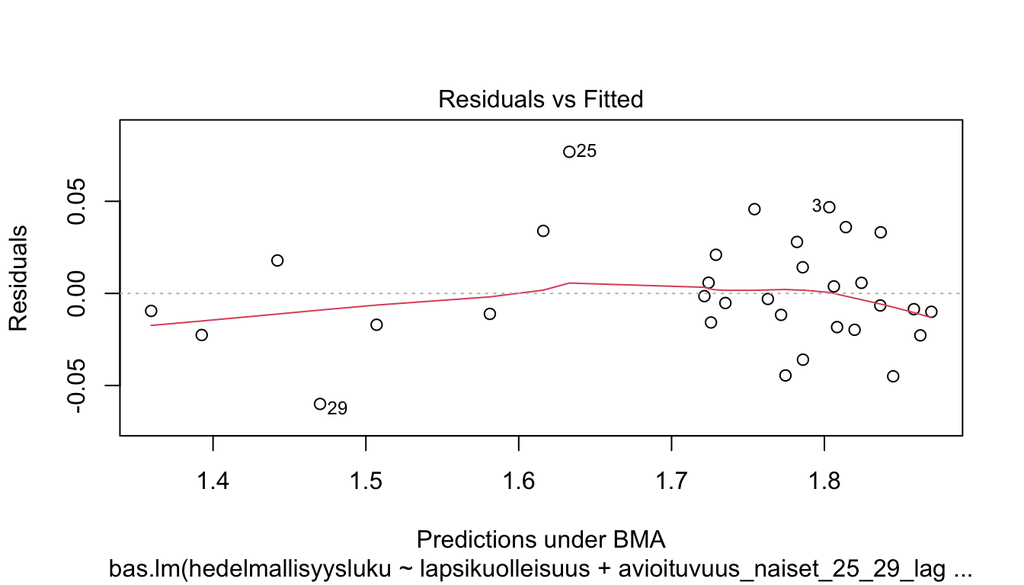

Ja lopuksi verrataan mallin sovitetta

# Ennuste

```
##
##  Marginal Posterior Summaries of Coefficients:
##
##  Using  BMA
##
##  Based on the top  59 models
##                                post mean   post SD     post p(B != 0)
## Intercept                       1.7200000   0.0060810   1.0000000
## lapsikuolleisuus               -1.1448653  13.3452359   0.1496094
## avioituvuus_naiset_25_29_lag1   0.0008057   0.0032848   0.1980469
## avioituvuus_naiset_30_34_lag1   0.0100843   0.0030498   0.9738281
## some_35_44_lag1                -0.0017645   0.0020565   0.5113281
## maaseudulla                     0.0374760   0.0199315   0.8660156
## some_25_44_diff_lag1            0.0037688   0.0025184   0.7691406
## dummy2021                       0.0385899   0.0613932   0.3609375
```

[output not shown]

Pyritään sitten arvioimaan miten hedelmällisyysluku kehittyy, mikäli 10 viime vuoden trendi jatkuisi näiden neljän tekijän osalta. Jatketaan trendiä lineaarisesti avioituvuudelle, kaupungistumiselle ja aktiivisten somen käyttäjien osuudelle. Muut tekijät pidetään vakiona.

```
## [1] "RMS for"           "2021"              ":"
## [4] "0.122380085304603"
```

ONESTEP

2018

2021

```
## [1] 0.09883469
```

```
## [1] 1.31
```

```
## [1] 1.211165
```

```
## [1] 0.2749042
```

```
##  [1] 1.8082951 1.8197592 1.8032126 1.7820619 1.8140302 1.8061982 1.7716533
##  [8] 1.7859699 1.7257804 1.7352121 1.7241988 1.7745345 1.7214762 1.7630264
## [15] 1.7542661 1.8449923 1.8627739 1.8242559 1.8585530 1.8699774 1.8368318
## [22] 1.8365551 1.7858140 1.7290360 1.6331286 1.6160614 1.5811237 1.5070091
## [29] 1.4700076 1.3595025 1.3925807 1.4421219 1.2111653 0.9950958 1.0682288
## [36] 1.0467651 0.9822299 0.8315109 0.8963670 0.8771374 0.8175534
```

datat

```
##  [1] 1990 1991 1992 1993 1994 1995 1996 1997 1998 1999 2000 2001 2002 2003 2004
## [16] 2005 2006 2007 2008 2009 2010 2011 2012 2013 2014 2015 2016 2017 2018 2019
## [31] 2020 2021 2022 2023 2024 2025 2026 2027 2028 2029 2030
```

```
##  [1]   NA   NA   NA   NA   NA   NA   NA   NA   NA   NA   NA   NA   NA   NA   NA
## [16]   NA   NA   NA   NA   NA   NA   NA   NA   NA   NA   NA   NA   NA 1.45
```

```
##  [1] 1.790000 1.800000 1.850000 1.810000 1.850000 1.810000 1.760000 1.750000
##  [9] 1.710000 1.730000 1.730000 1.730000 1.720000 1.760000 1.800000 1.800000
## [17] 1.840000 1.830000 1.850000 1.860000 1.870000 1.830000 1.800000 1.750000
## [25] 1.710000 1.650000 1.570000 1.490000       NA 1.350000 1.370000 1.460000
## [33] 1.577297 1.731121       NA       NA       NA       NA       NA       NA
## [41]       NA
```

```
##  [1]   NA   NA   NA   NA   NA   NA   NA   NA   NA   NA   NA   NA   NA   NA   NA
## [16]   NA   NA   NA   NA   NA   NA   NA   NA   NA   NA   NA   NA 1.49 1.41 1.35
## [31] 1.37 1.46 1.31 1.27   NA   NA   NA   NA   NA   NA   NA
```

```
##  [1]        NA        NA        NA        NA        NA        NA        NA
##  [8]        NA        NA        NA        NA        NA        NA        NA
## [15]        NA        NA        NA        NA        NA        NA        NA
## [22]        NA        NA        NA        NA        NA        NA        NA
## [29]        NA        NA        NA 1.4421219 1.2111653 0.9950958 1.0682288
## [36] 1.0467651 0.9822299 0.8315109 0.8963670 0.8771374 0.8175534
```

```
##  [1]   NA   NA   NA   NA   NA   NA   NA   NA   NA   NA   NA   NA   NA   NA   NA
## [16]   NA   NA   NA   NA   NA   NA   NA   NA   NA   NA   NA   NA 1.49 1.41 1.33
## [31] 1.25 1.17 1.09 1.01   NA   NA   NA   NA   NA   NA   NA
```

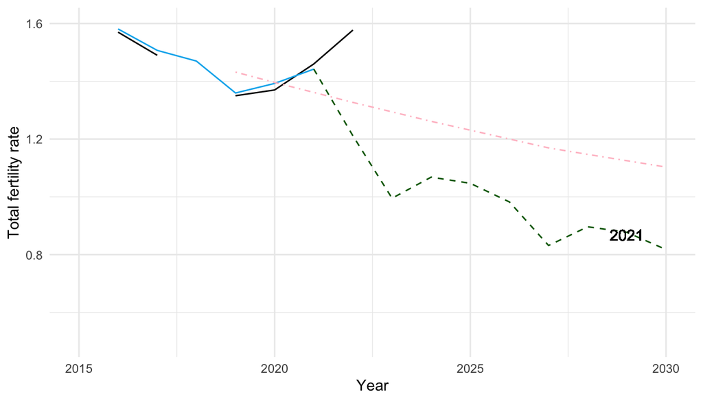

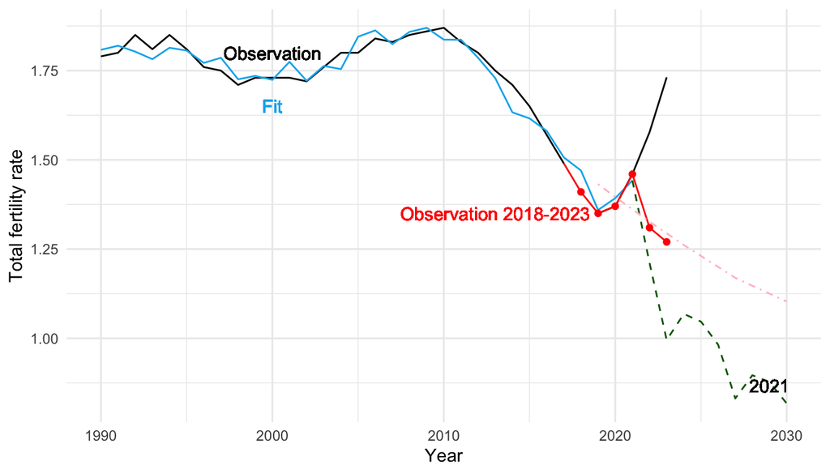

datat

```
##    year     lower   higher   ennuste      tfr
## 1  1990        NA       NA        NA 1.808295
## 2  1991        NA       NA        NA 1.819759
## 3  1992        NA       NA        NA 1.803213
## 4  1993        NA       NA        NA 1.782062
## 5  1994        NA       NA        NA 1.814030
## 6  1995        NA       NA        NA 1.806198
## 7  1996        NA       NA        NA 1.771653
## 8  1997        NA       NA        NA 1.785970
## 9  1998        NA       NA        NA 1.725780
## 10 1999        NA       NA        NA 1.735212
## 11 2000        NA       NA        NA 1.724199
## 12 2001        NA       NA        NA 1.774534
## 13 2002        NA       NA        NA 1.721476
## 14 2003        NA       NA        NA 1.763026
```

[output cut: 27 more lines]

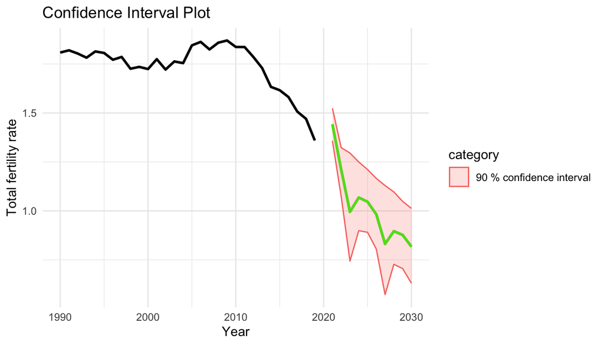